# Labor Markets and Unemployment

March 24, 2025

## Measuring Unemployment

## Unemployment

There are a variety of types of unemployment, and all types are not created equal.

Some unemployment is an unavoidable and necessary consequence of economic growth, as economic progress inevitably renders some jobs obsolete.

- Employment in fields like farming have declined significantly over the past 150 years, and some jobs have essentially disappeared (telephone switchboard operators, wagonmakers, etc.).
- These jobs are destroyed because of the appearance of new jobs in areas like IT server technician and automotive engineer.

## Unemployment

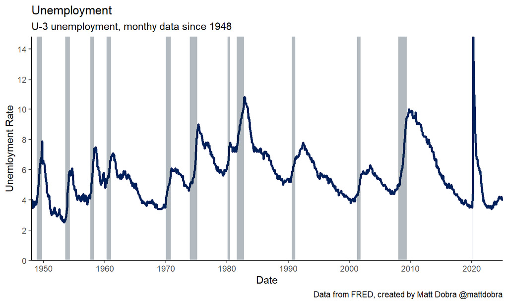

The key measure that economists look at in the US is the U-3 Unemployment rate.

The unemployment rate as of February, 2025 is 4.1%.

## Unemployment

To calculate the unemployment rate, the population must first be subdivided into a number of smaller groups.

## Unemployment

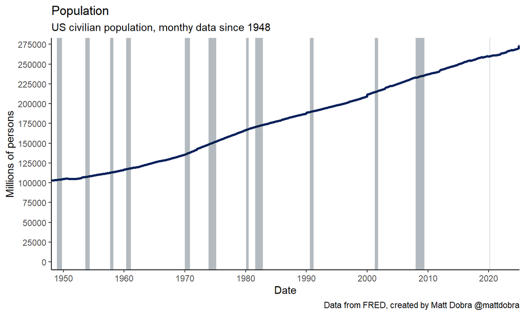

**Civilian Noninstitutional Population**: Number of people in the US or DC, over 16, not inmates or institutionalized, or in the Armed Forces.

As of February, 2025, this figure for the US is 272.85 million.

## Unemployment

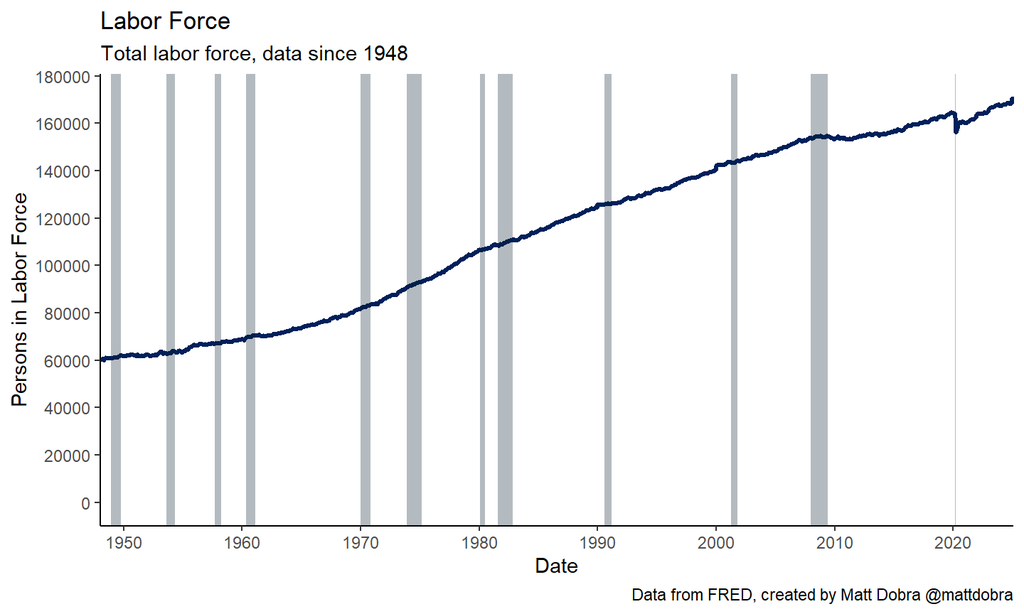

**Labor Force**: Civilian noninstitutionalized population, less retirees, students, homemakers, and people just not looking for work.

As of February, 2025, the US labor force numbered 170.36 million people.

## Unemployment

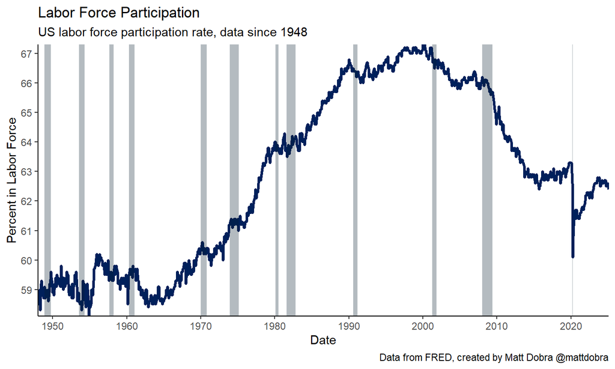

**Labor Force Participation Rate**: The percentage of the civilian population that is in the labor force.

As of February, 2025, the US labor force participation rate was 62.4%.

## Unemployment

The labor force participation rate is heavily influenced by demographics.

it is also influenced by incentives – high tax rates and generous welfare benefits reduce the participation rate.

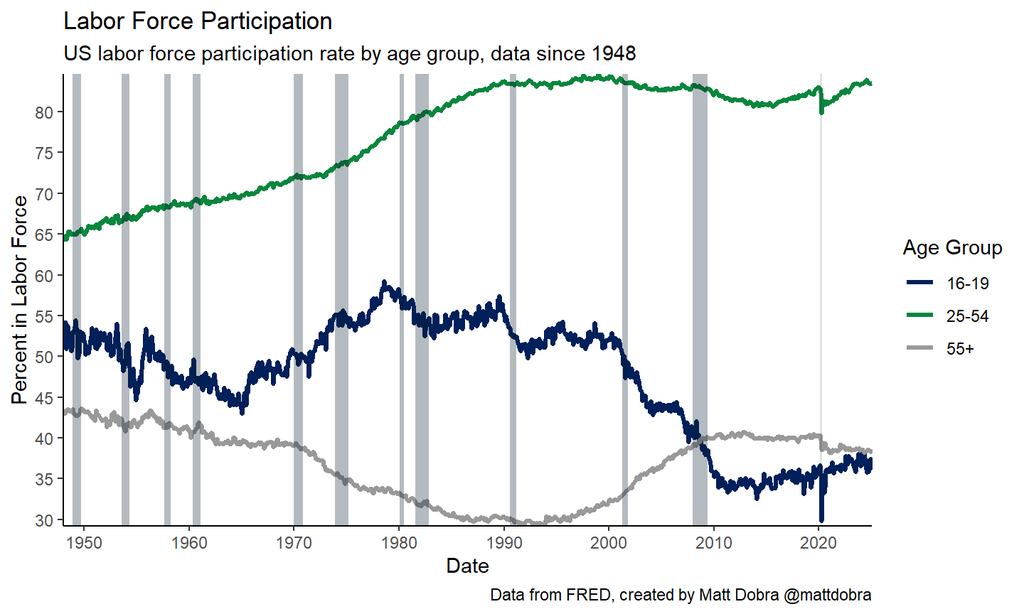

## Unemployment

A person is **unemployed** only if he or she is in the labor force, is actively looking for work, but cannot find a job.

The **unemployment rate** is then given by:

\(Unemployment \: Rate = \frac{\# \: of \: Unemployed}{Labor \: Force}\)

As of February, 2025, the US labor force numbered 170.36 million people, of which 7.05 million were unemployed. This implies an unemployment rate of:

\(4.1\% = \frac{7.05 \: million }{170.36 \: million}\)

## Unemployment

From an individual perspective, unemployment, especially if it is long term unemployment, can be both financial and psychologically devastating.

From a economy-wide perspective, unemployment means that the economy is under-performing.

While the unemployment rate is arguably the *best* indicator of the labor market, it is not the whole story.

- The unemployment rate misses discouraged and underemployed workers.

## Unemployment

A **discouraged worker** is someone who is not currently looking for a job because they believe they will not find one, but has looked for work within the past year.

Discouraged workers are included in the U-4, which is typically a little higher than the U-3.

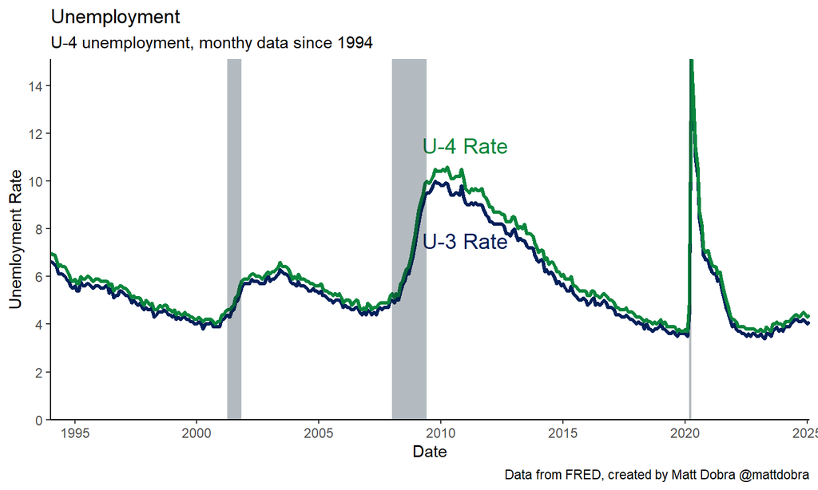

## Unemployment

The broadest measure of unemployment is the U-6, which includes discouraged, marginally attached, and underemployed workers.

A **marginally attached worker** someone who has either looked for work or held a job in the past year, but is not currently looking.

U-3 considers somebody employed if they worked as little as one hour. However, many people working part time would prefer to work full time but cannot find a full time job. These people are classified as **underemployed workers**.

## Unemployment

While the U-3 unemployment rate in February, 2025 was 4.1%, the U-6 unemployment rate was 8%.

The gap between the U-6 and the U-3 is large and grew following the great recession.

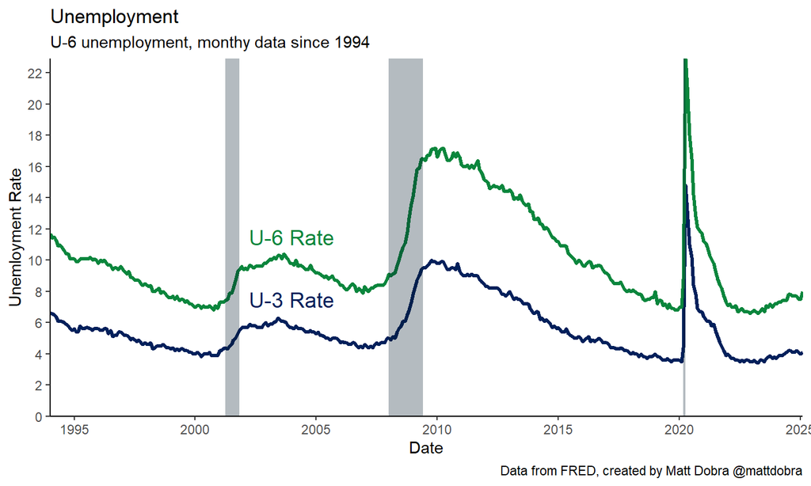

## Types of Unemployment

## Types of Unemployment

The three main types of unemployment are:

- Frictional Unemployment
- Structural Unemployment
- Cyclical Unemployment

## Frictional Unemployment

**Frictional Unemployment** is (typically) short term unemployment caused by the difficulties that exist in matching potential employees with jobs.

Many people who are frictionally unemployed are unemployed by choice, as this includes people leaving their jobs to find new ones. It also includes recent college graduates, stay-at-home parents returning to the workforce, etc.

For the most part, frictional unemployment is good for the economy.

## Frictional Unemployment

Economist Joseph Schumpeter coined the term **creative destruction** to describe the constant process of product and process innovation that replaces old products and processes.

Schumpeter called creative destruction “the essential fact of capitalism”

Innovation and competition drive economic growth, creating new jobs and destroying old jobs.

Official government figures mask the creative destruction process.

- For example, the number people focus on in the jobs report is the number of new jobs in a month. In August 2018, this number was 78,000.
- The 78,000 figure is arrived at by taking the difference between the number of new hires, 5.784 million, and the number of job separations, 5.706 million.

## Structural Unemployment

**Structural unemployment** is persistent, typically long-term unemployment that is caused by long-lasting shocks or permanent features of an economy that prevent the labor market from working effectively.

Structural unemployment can result from a number of economic forces:

- economy-wide shocks, like oil shocks (or pandemics?).
- globalization
- new IT
- shifting from manufacturing to services

## Structural Unemployment

Structural unemployment has significant economic and social costs.

- Lowered economic output
- Psychological costs on the unemployed, such as elevated suicide rates and reduced happiness.

## Structural Unemployment

Structural unemployment is a larger problem in countries with strong labor market regulations.

A 2019 OECD study measured the strictness of labor market regulations.

Having more and stronger regulations is positively correlated with duration of unemployment

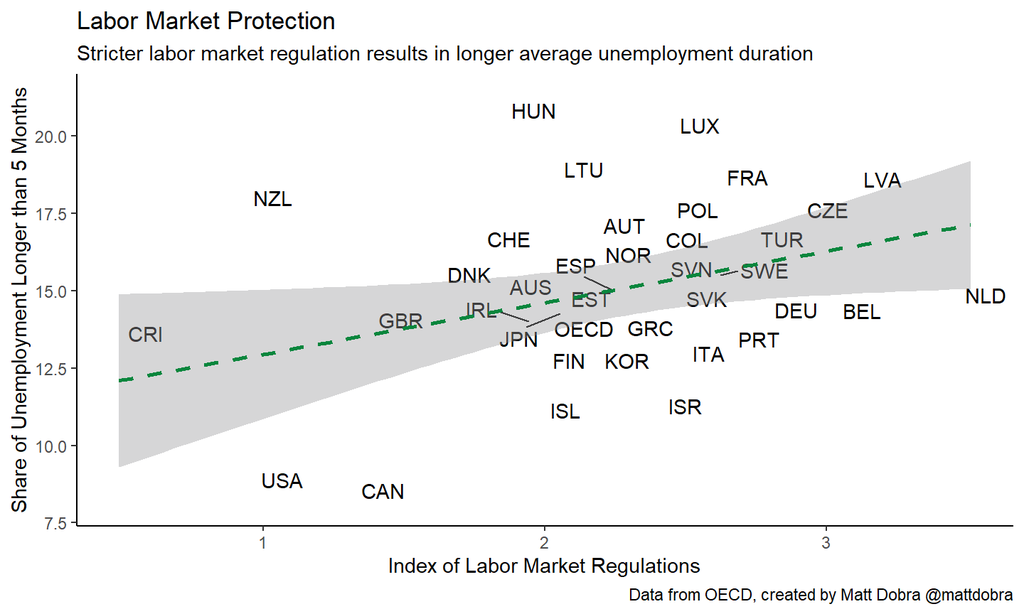

## Structural Unemployment

Labor market regulations generally have the following effects:

- Create insurance for workers, particularly those workers who have full-time jobs.
- Make it harder to find a full-time job.
- Reduce the efficiency of labor markets.
- Increase the duration of unemployment.
- Increase the amount of unemployment, particularly among young, minority, or “risky” workers.
  - e.g. ex-convicts, people you know little about, high variance workers…

## Structural Unemployment

Minimum wages also increase unemployment.

The higher the minimum wage is relative to the market wage, the greater the unemployment created.

This implies that countries with higher minimum wages (relative to market wages) should have more unemployment.

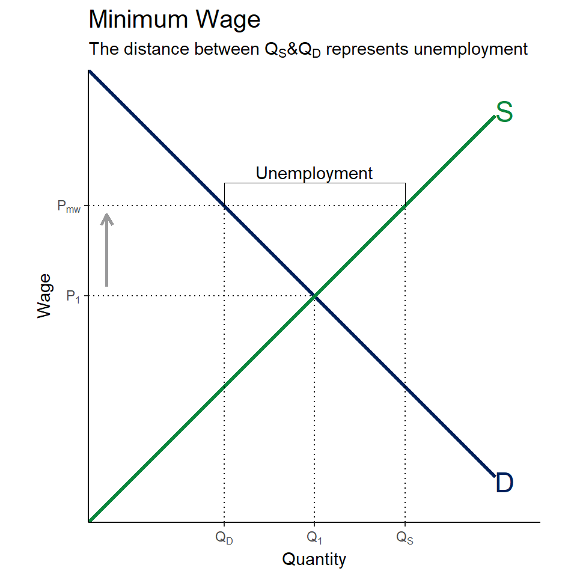

## Structural Unemployment

The **Kaitz index** is a measure of how high the minimum wage is in any given area.

\(Kaitz\;Index=\frac{Minimum\:Wage}{Median\:Wage}\)

The median wage is the wage such that half of all workers earn more the median and half of all workers earn less than the median.

## Structural Unemployment

The Kaitz index is often use as a shorthand to estimate the potential harm of a minimum wage.

- If Kaitz<40%, the general consensus is that the minimum wage is too low to have a noticeable unemployment effect.
- If Kaitz>60%, most economists believe that the minimum wage will have a large unemployment effect.
- There is no general consensus on the 40%-60% range.

## Structural Unemployment

The Kaitz index varies widely across OECD countries.

Countries tend to lie in the range between 40% and 60%, but not all do.

Note that this graph is based on federal minimum wages, and local minimum wages may be higher.

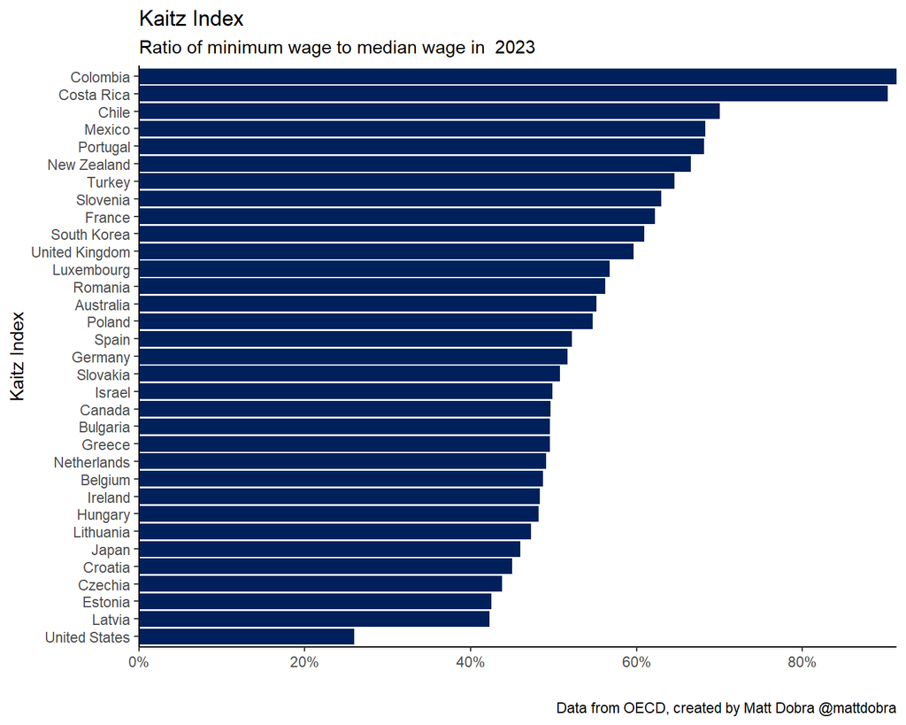

## Structural Unemployment

There is generally an increasing relationship between the Kaitz Index and unemployment rates.

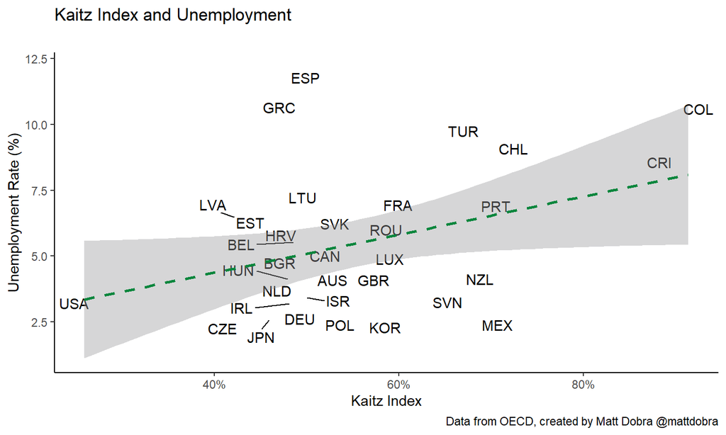

## Structural Unemployment

There are also policies that can reduce structural unemployment:

**At-Will Employment** refers to a labor market in which a worker can be fired or quit at any time for any reason, so long as that reason is not illegal (discrimination, etc.).

**Active Labor Market Policies** are (typically) government programs designed to help unemployed workers find jobs by:

- enhancing their motivation and incentives to find work
- improving their job readiness and skills through education or job retraining programs
- improving their job search skills and assisting with their job search

## Cyclical Unemployment

**Cyclical Unemployment** is unemployment that is correlated with the business cycle.

Generally speaking, unemployment increases during a recession.

When GDP falls, firms fire workers, thus increasing unemployment.

## Cyclical Unemployment

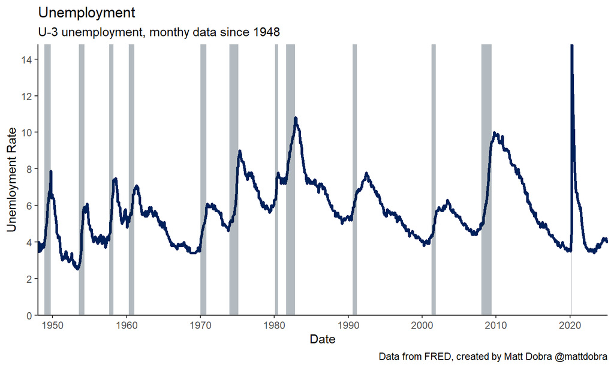

Consider again the U-3 unemployment graph.

Unemployment rates generally spike during recessions and slowly fall afterwards.

## Cyclical Unemployment

Cyclical unemployment can change dramatically in a very short time period.

For example, consider the unemployment rate for the months immediately surrounding the Covid-19 crisis in 2020:

| Month | Unemploment Rate |
| --- | --- |
| January | 3.6 |
| February | 3.5 |
| March | 4.4 |
| April | 14.8 |
| May | 13.2 |
| June | 11.0 |

## Cyclical Unemployment

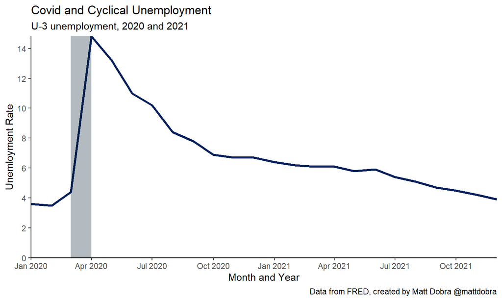

Zooming in on the U-3 graph to 2020 and 2021 shows the cyclical unemployment impact of Covid.

Even with the Covid recovery being remarkably quick, the recovery is still much slower than the initial shock.

## Natural Rate of Unemployment

The **Natural Rate of Unemployment** is calculated by summing the frictional and structural rates of unemployment.

The natural rate changes very slowly - The factors that influence structural and frictional unemployment change slowly

This is unlike the regular unemployment rate which includes cyclical unemployment

## Natural Rate of Unemployment

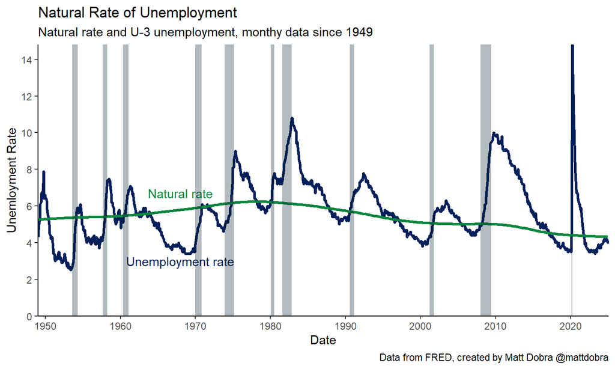

The natural rate is far more stable than the U-3 rate.

Some economists believe that the risk of inflation increases when unemployment falls below the natural rate.